# Mirza - LING 583 Final Project

## Student Name - Mirza Ishraq Yeahia

## Final Project LING 583

```python
import numpy as np
import pandas as pd
import re
import nltk
import matplotlib.pyplot as plt
import seaborn as sns
```

```python
trump = pd.read_csv("hashtag_donaldtrump.csv",lineterminator='\n')
biden = pd.read_csv("hashtag_joebiden.csv",lineterminator='\n')
```

```python
trump.head()
```

|  | created_at | tweet_id | tweet | likes | retweet_count | source | user_id | user_name | user_screen_name | user_description | ... | user_followers_count | user_location | lat | long | city | country | continent | state | state_code | collected_at |
| --- | --- | --- | --- | --- | --- | --- | --- | --- | --- | --- | --- | --- | --- | --- | --- | --- | --- | --- | --- | --- | --- |
| 0 | 2020-10-15 00:00:01 | 1.316529e+18 | #Elecciones2020 \| En #Florida: #JoeBiden dice ... | 0.0 | 0.0 | TweetDeck | 3.606665e+08 | El Sol Latino News | elsollatinonews | 🌐 Noticias de interés para latinos de la costa... | ... | 1860.0 | Philadelphia, PA / Miami, FL | 25.774270 | -80.193660 | NaN | United States of America | North America | Florida | FL | 2020-10-21 00:00:00 |
| 1 | 2020-10-15 00:00:01 | 1.316529e+18 | Usa 2020, Trump contro Facebook e Twitter: cop... | 26.0 | 9.0 | Social Mediaset | 3.316176e+08 | Tgcom24 | MediasetTgcom24 | Profilo ufficiale di Tgcom24: tutte le notizie... | ... | 1067661.0 | NaN | NaN | NaN | NaN | NaN | NaN | NaN | NaN | 2020-10-21 00:00:00.373216530 |
| 2 | 2020-10-15 00:00:02 | 1.316529e+18 | #Trump: As a student I used to hear for years,... | 2.0 | 1.0 | Twitter Web App | 8.436472e+06 | snarke | snarke | Will mock for food! Freelance writer, blogger,... | ... | 1185.0 | Portland | 45.520247 | -122.674195 | Portland | United States of America | North America | Oregon | OR | 2020-10-21 00:00:00.746433060 |
| 3 | 2020-10-15 00:00:02 | 1.316529e+18 | 2 hours since last tweet from #Trump! Maybe he... | 0.0 | 0.0 | Trumpytweeter | 8.283556e+17 | Trumpytweeter | trumpytweeter | If he doesn't tweet for some time, should we b... | ... | 32.0 | NaN | NaN | NaN | NaN | NaN | NaN | NaN | NaN | 2020-10-21 00:00:01.119649591 |
| 4 | 2020-10-15 00:00:08 | 1.316529e+18 | You get a tie! And you get a tie! #Trump ‘s ra... | 4.0 | 3.0 | Twitter for iPhone | 4.741380e+07 | Rana Abtar - رنا أبتر | Ranaabtar | Washington Correspondent, Lebanese-American ,c... | ... | 5393.0 | Washington DC | 38.894992 | -77.036558 | Washington | United States of America | North America | District of Columbia | DC | 2020-10-21 00:00:01.492866121 |

5 rows × 21 columns

```python
biden.head()
```

|  | created_at | tweet_id | tweet | likes | retweet_count | source | user_id | user_name | user_screen_name | user_description | ... | user_followers_count | user_location | lat | long | city | country | continent | state | state_code | collected_at |
| --- | --- | --- | --- | --- | --- | --- | --- | --- | --- | --- | --- | --- | --- | --- | --- | --- | --- | --- | --- | --- | --- |
| 0 | 2020-10-15 00:00:01 | 1.316529e+18 | #Elecciones2020 \| En #Florida: #JoeBiden dice ... | 0.0 | 0.0 | TweetDeck | 3.606665e+08 | El Sol Latino News | elsollatinonews | 🌐 Noticias de interés para latinos de la costa... | ... | 1860.0 | Philadelphia, PA / Miami, FL | 25.774270 | -80.193660 | NaN | United States of America | North America | Florida | FL | 2020-10-21 00:00:00 |
| 1 | 2020-10-15 00:00:18 | 1.316529e+18 | #HunterBiden #HunterBidenEmails #JoeBiden #Joe... | 0.0 | 0.0 | Twitter for iPad | 8.099044e+08 | Cheri A. 🇺🇸 | Biloximeemaw | Locked and loaded Meemaw. Love God, my family ... | ... | 6628.0 | NaN | NaN | NaN | NaN | NaN | NaN | NaN | NaN | 2020-10-21 00:00:00.517827283 |
| 2 | 2020-10-15 00:00:20 | 1.316529e+18 | @IslandGirlPRV @BradBeauregardJ @MeidasTouch T... | 0.0 | 0.0 | Twitter Web App | 3.494182e+09 | Flag Waver | Flag_Wavers | NaN | ... | 1536.0 | Golden Valley Arizona | 46.304036 | -109.171431 | NaN | United States of America | North America | Montana | MT | 2020-10-21 00:00:01.035654566 |
| 3 | 2020-10-15 00:00:21 | 1.316529e+18 | @chrislongview Watching and setting dvr. Let’s... | 0.0 | 0.0 | Twitter for iPhone | 8.242596e+17 | Michelle Ferg | MichelleFerg4 | NaN | ... | 27.0 | NaN | NaN | NaN | NaN | NaN | NaN | NaN | NaN | 2020-10-21 00:00:01.553481849 |
| 4 | 2020-10-15 00:00:22 | 1.316529e+18 | #censorship #HunterBiden #Biden #BidenEmails #... | 1.0 | 0.0 | Twitter Web App | 1.032807e+18 | the Gold State | theegoldstate | A Silicon Valley #independent #News #Media #St... | ... | 390.0 | California, USA | 36.701463 | -118.755997 | NaN | United States of America | North America | California | CA | 2020-10-21 00:00:02.071309132 |

5 rows × 21 columns

### Preprocessing & Data Cleaning

(Not in particular order)

1. From our two data sets I only need the tweets and who is the tweet about. So I am going to create an extra column on each of the dataframe to identify the whos the tweet about.
2. Drop the columns that I don't need.
3. Clean out the numbers, especial characters and numerical values.
4. Merge the two dataset.
5. Some other steps which may not be mentioned here.

```python
trump['Candidate'] = 'Trump'
biden['Candidate'] = 'Biden'
```

```python
trumpDf = trump[['Candidate','tweet']]
bidenDf = biden[['Candidate','tweet']]
```

```python
df = pd.concat([trumpDf, bidenDf])
df
```

|  | Candidate | tweet |
| --- | --- | --- |
| 0 | Trump | #Elecciones2020 \| En #Florida: #JoeBiden dice ... |
| 1 | Trump | Usa 2020, Trump contro Facebook e Twitter: cop... |
| 2 | Trump | #Trump: As a student I used to hear for years,... |
| 3 | Trump | 2 hours since last tweet from #Trump! Maybe he... |
| 4 | Trump | You get a tie! And you get a tie! #Trump ‘s ra... |
| ... | ... | ... |
| 776881 | Biden | Stop laying @CNN !\n#Paris and #London dont gi... |
| 776882 | Biden | Ωχ ελπίζω να μη μας βγει σαν τους οπαδούς του... |
| 776883 | Biden | L'OTAN va sortir de sa léthargie et redevenir ... |
| 776884 | Biden | 🌎\n\n“#congiuntifuoriregione”\n\n‘Sono felice ... |
| 776885 | Biden | Ik moet zeggen dat ik #Biden "the lesser of tw... |

1747805 rows × 2 columns

```python
from nltk.corpus import stopwords
from nltk import WordNetLemmatizer
from nltk.stem import SnowballStemmer
```

```python
df.isnull().sum()
```

```
Candidate    0
tweet        0
dtype: int64
```

```python
# Remove stop words.

stop=set(stopwords.words("english"))
lemma=WordNetLemmatizer()

def removeStopword(text):
   text=[word.lower() for word in text.split() if word.lower() not in stop]
   return " ".join(text)
```

```python
df['tweet'] = df['tweet'].apply(removeStopword)
```

```python
df.head()
```

|  | Candidate | tweet |
| --- | --- | --- |
| 0 | Trump | #elecciones2020 \| en #florida: #joebiden dice ... |
| 1 | Trump | usa 2020, trump contro facebook e twitter: cop... |
| 2 | Trump | #trump: student used hear years, ten years, he... |
| 3 | Trump | 2 hours since last tweet #trump! maybe busy. t... |
| 4 | Trump | get tie! get tie! #trump ‘s rally #iowa https:... |

```python
# Remove punctuation.

def removePunc(text):
    import string as st
    t=[w for w in text if w not in st.punctuation]
    return ''.join(t)


def removeSymbols(x):
    t = re.sub(r"[^a-zA-Z0-9?!.,]+", ' ', x)
    return t


df['tweet'] = df['tweet'].apply(removePunc)
df['tweet'] = df['tweet'].apply(removeSymbols)
```

```python
df.head()
```

|  | Candidate | tweet |
| --- | --- | --- |
| 0 | Trump | elecciones2020 en florida joebiden dice que do... |
| 1 | Trump | usa 2020 trump contro facebook e twitter copro... |
| 2 | Trump | trump student used hear years ten years heard ... |
| 3 | Trump | 2 hours since last tweet trump maybe busy trem... |
| 4 | Trump | get tie get tie trump s rally iowa httpstcojja... |

```python
# Normalize through stemming

def stemming(text):
   stem=[]
   stopword = stopwords.words('english')
   ss = SnowballStemmer('english')
   tokens = nltk.word_tokenize(text)
   text = [ss.stem(word) for word in tokens]
   result=' '.join(text)
   return result
```

```python
df['tweet'] = df['tweet'].apply(stemming)
```

```python
df['tweet'] = df['tweet'].str.lower()
```

```python
def removeNum(texts):
   out = re.sub(r'\d+', '', texts)
   return out


df['tweet'] = df['tweet'].apply(removeNum)
```

### NLTK Sentiment Analyzer - VADER

```python
from nltk.sentiment import SentimentIntensityAnalyzer
```

```python
sentimentIns = SentimentIntensityAnalyzer()
```

```python
def implementVader(text):
    return sentimentIns.polarity_scores(text)['compound']
```

```python
df['sentiments'] = df['tweet'].apply(implementVader)
```

```python
# Set labels

def categorise(sentiment, neg_threshold=-0.05, pos_threshold=0.05):
    if sentiment < neg_threshold:
        label = 'negative'
    elif sentiment > pos_threshold:
        label = 'positive'
    else:
        label = 'neutral'
    return label
```

```python
df['tweetSentiment'] = df['sentiments'].apply(categorise)
df = df[['Candidate','tweet','tweetSentiment']]
df.head()
```

|  | Candidate | tweet | tweetSentiment |
| --- | --- | --- | --- |
| 0 | Trump | elecciones en florida joebiden dice que donald... | neutral |
| 1 | Trump | usa trump contro facebook e twitter coprono b... | neutral |
| 2 | Trump | trump student use hear year ten year heard chi... | positive |
| 3 | Trump | hour sinc last tweet trump mayb busi tremend ... | neutral |
| 4 | Trump | get tie get tie trump s ralli iowa httpstcojja... | neutral |

### Word Cloud

```python
from wordcloud import WordCloud, STOPWORDS, ImageColorGenerator

def word_cloud(wd_list):
    stopwords = set(STOPWORDS)
    all_words = ' '.join([text for text in wd_list])
    wordcloud = WordCloud(
        background_color='white',
        stopwords=stopwords,
        width=1600,
        height=800,
        random_state=1,
        colormap='jet',
        max_words=80,
        max_font_size=200).generate(all_words)
    plt.figure(figsize=(12, 10))
    plt.axis('off')
    plt.imshow(wordcloud, interpolation="bilinear")
```

```python
trumpSentiments = df[df['Candidate'] == 'Trump']
```

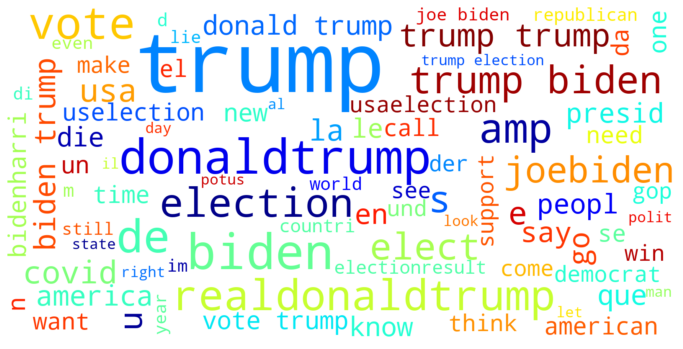

```python
word_cloud(trumpSentiments['tweet'].sample(10000))
```

```python
bidenSentiments = df[df['Candidate'] == 'Biden']
```

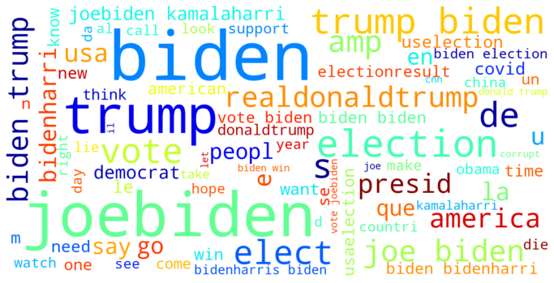

```python
word_cloud(bidenSentiments['tweet'].sample(10000))
```